# Customer Success Analysis for Swire Coca-Cola

Vicky Mao, Katelyn Candee, Li Xiang

2023-04-04

# 1 Business Problem

Swire Coca-Cola is seeking a solution to predicting the longevity and profit of new potential customer from local businesses.

# 2 Analytics objective

# 3 Questions

1.What target variables should be used to predict customer success ?

2.What kind of relationships are found between target variables and predictors ?

3.What Census data should be used ？

4.Which predictors should be included ?

5.Which prediction models should be used?

6.What are the common characteristics of well-performing customers based on prediction outcomes?

# 4 Approach

To solve the business problem, we will first start by cleaning, filtering and combing the datasets as well as adding census data. Second of all, we will explore the combined data, looking for patterns, trends, variable importance and relationships. After deciding our predictors, we will test out a few prediction models and select our best model based on model performances. Finally, we plan to look for characteristics of “successful” customers based on preciction outcomes and provide the sponsor a conclusion and suggestions.

# 5 Details

This project will be completed by student team members Katelyn Candee, Li Xiang and Vicky Mao by April 13, with progress checkpoints overseen by University of Utah faculty advisor Jeremy Morris on or before the following dates:  
1. Exploratory data analysis - February 19  
2. Model selection, evaluation and deployment - March 19  
3. Practice project presentation - April 9

Project team members may be reach at:  
1. Katelyn Candee - (203) 823-3129 - u1398566@utah.com  
2. Li Xiang - (385) 335-4332 - u1328517@utah.edu  
3. Vicky Mao - (801) 970-0482 - u1132288@utah.edu

# 6 Data Pre-processing

Read & Summarize Data

```r
# Load packages
library(tidyverse)
library(dplyr)

# Set working directory
setwd("~/Desktop/Capstone/")

# Import data sets
customer <- read.csv("FSOP_Customer_Data_v2.0.csv", stringsAsFactors = FALSE)
sales <- read.csv("FSOP_Sales_Data_v2.0.csv", stringsAsFactors = FALSE)

# View Datasets
summary(customer)
```

```
##  CUSTOMER_NUMBER_BLINDED SALES_OFFICE_DESCRIPTION DELIVERY_PLANT_DESCRIPTION
##  Length:40386            Length:40386             Length:40386
##  Class :character        Class :character         Class :character
##  Mode  :character        Mode  :character         Mode  :character
##
##
##
##  ON_BOARDING_DATE   ADDRESS_CITY       ADDRESS_ZIP_CODE      COUNTY
##  Length:40386       Length:40386       Length:40386       Length:40386
##  Class :character   Class :character   Class :character   Class :character
##  Mode  :character   Mode  :character   Mode  :character   Mode  :character
##
##
##
##  GEO_LONGITUDE     GEO_LATITUDE   CUSTOMER_ACTIVITY_CLUSTER_DESCRIPTION
##  Min.   :-124.6   Min.   : 0.00   Length:40386
##  1st Qu.:-121.3   1st Qu.:37.42   Class :character
##  Median :-112.1   Median :40.60   Mode  :character
##  Mean   :-114.1   Mean   :40.81
##  3rd Qu.:-111.0   3rd Qu.:45.51
##  Max.   :   0.0   Max.   :49.00
##  CUSTOMER_TRADE_CHANNEL_DESCRIPTION CUSTOMER_SUB_TRADE_CHANNEL_DESCRIPTION
##  Length:40386                       Length:40386
##  Class :character                   Class :character
##  Mode  :character                   Mode  :character
##
##
##
##  BUSINESS_TYPE_EXTENSION_DESCRIPTION CUSTOMER_TRADE_CHANNEL_DESCRIPTION2
##  Length:40386                        Length:40386
##  Class :character                    Class :character
##  Mode  :character                    Mode  :character
##
##
##
##  MARKET_DESCRIPTION COLD_DRINK_CHANNEL_DESCRIPTION
##  Length:40386       Length:40386
##  Class :character   Class :character
##  Mode  :character   Mode  :character
##
##
##
```

```r
summary(sales)
```

```
##  CUSTOMER_NUMBER_BLINDED PRODUCT_SOLD_BLINDED BEV_CAT_DESC
##  Length:831858           Length:831858        Length:831858
##  Class :character        Class :character     Class :character
##  Mode  :character        Mode  :character     Mode  :character
##
##
##
##  CALORIE_CAT_DESC   PACK_TYPE_DESC     PACK_SIZE_SALES_UNIT_DESCRIPTION
##  Length:831858      Length:831858      Length:831858
##  Class :character   Class :character   Class :character
##  Mode  :character   Mode  :character   Mode  :character
##
##
##
##  PHYSICAL_VOLUME        DISCOUNT         INVOICE_PRICE
##  Min.   :-65832.00   Min.   : -13902.0   Min.   : -22982.4
##  1st Qu.:     1.00   1st Qu.:     17.6   1st Qu.:     31.1
##  Median :     5.00   Median :     90.0   Median :    136.8
##  Mean   :    36.22   Mean   :   1003.8   Mean   :    926.5
##  3rd Qu.:    17.00   3rd Qu.:    413.4   3rd Qu.:    523.4
##  Max.   :136349.00   Max.   :2847661.8   Max.   :1813003.8
##     DEAD_NET         GROSS_PROFIT_DEAD_NET      COGS
##  Min.   : -34534.1   Min.   :-145562.4     Min.   :  -7392.3
##  1st Qu.:     29.3   1st Qu.:      8.6     1st Qu.:     12.5
##  Median :    130.0   Median :     44.8     Median :     72.7
##  Mean   :    845.3   Mean   :    295.0     Mean   :    580.3
##  3rd Qu.:    500.0   3rd Qu.:    181.9     3rd Qu.:    297.7
##  Max.   :1813003.8   Max.   : 883618.1     Max.   :1370468.2
##  MIN_POSTING_DATE   MAX_POSTING_DATE   NUM_OF_TRANSACTIONS
##  Length:831858      Length:831858      Min.   :  1.00
##  Class :character   Class :character   1st Qu.:  2.00
##  Mode  :character   Mode  :character   Median :  7.00
##                                        Mean   : 21.23
##                                        3rd Qu.: 24.00
##                                        Max.   :468.00
```

From the sale data, we extract total sales,Discount,Invoice Price… and overall maximum posting date by Customer Number. Maximum posting date will be used later to calculate one of our target variables, “Customer Longevity”.

```r
# Convert date variables to dates
sales$MIN_POSTING_DATE <- as.Date(sales$MIN_POSTING_DATE)
sales$MAX_POSTING_DATE <- as.Date(sales$MAX_POSTING_DATE)
#customer$ON_BOARDING_DATE <- as.Date(customer$ON_BOARDING_DATE, format = "%m/%d/%Y")

# Convert remaining character type variables to factors
sales <- sales %>%
  mutate_if(is.character, as.factor)

# Extract total sales and maximum max posting date by customer
sales <- sales %>%
  group_by(CUSTOMER_NUMBER_BLINDED) %>%
  summarize(GROSS_PROFIT_DEAD_NET = sum(GROSS_PROFIT_DEAD_NET),
             DISCOUNT = sum( DISCOUNT),
            INVOICE_PRICE = sum(INVOICE_PRICE),
            DEAD_NET = sum(DEAD_NET),
            PHYSICAL_VOLUME = sum(PHYSICAL_VOLUME),
            COGS = sum(COGS),
            NUM_OF_TRANSACTIONS = sum(NUM_OF_TRANSACTIONS),
            MIN_POSTING_DATE = min(MIN_POSTING_DATE),
            MAX_POSTING_DATE = max(MAX_POSTING_DATE))
```

Add “state” to customer data set. This will be used to request American Community Survey data from the Census Bureau.

```r
#library(zipcodeR)

# Clean zip codes
customer$ADDRESS_ZIP_CODE <- substr(customer$ADDRESS_ZIP_CODE, 0, 5)

# Obtain data frame of states by zip code
zipcode_state <- zipcodeR::zip_code_db %>%
  select(zipcode, state) %>%
  rename(ADDRESS_ZIP_CODE = zipcode,
         ADDRESS_STATE = state)

# Merge states with customer data set and filter to only UT customers
customer <- left_join(customer, zipcode_state, by = "ADDRESS_ZIP_CODE") %>%
  filter(ADDRESS_STATE == "UT")

# Check for missing state values after merge
sum(is.na(customer$ADDRESS_STATE))
```

```
## [1] 0
```

```r
# Identify city-zip code combinations missing values for imputing
customer[is.na(customer$ADDRESS_STATE), ] %>%
  select(ADDRESS_CITY, ADDRESS_ZIP_CODE, ADDRESS_STATE) %>%
  distinct(ADDRESS_CITY, ADDRESS_ZIP_CODE)
```

```
## [1] ADDRESS_CITY     ADDRESS_ZIP_CODE
## <0 rows> (or 0-length row.names)
```

```r
# Recheck for missing state values after merge
sum(is.na(customer$ADDRESS_STATE))
```

```
## [1] 0
```

```r
# Convert all character type variables to factor type
customer <- customer %>%
  mutate_if(is.character, as.factor)
```

The focus of this analysis is Swire Coca-Cola’s B2B restaurant segment, so we filter our sample to include only customers assigned the “Eating & Drinking” activity cluster and labelled as a “Direct Store Delivery (DSD)” business type.

```r
# Save filtered customer data set
customer <- customer %>%
  filter(CUSTOMER_ACTIVITY_CLUSTER_DESCRIPTION == "Eating & Drinking" &
           BUSINESS_TYPE_EXTENSION_DESCRIPTION == "DSD")
```

Extract the following information by “county” from the American Community Survey administered by the U.S. Census Bureau: * Total population * Median household income (in the last 12 months) * Median gross rent * Median monthly housing costs * Selected monthly owner costs * Average household size * Aggregate number of vehicles used to commute to work * Median year structure built * Number of households without internet access

```r
library(tidycensus)
# Store key for Census Bureau API
census_key <- readLines("census_key.txt")
census_api_key(census_key)
```

```
## To install your API key for use in future sessions, run this function with `install = TRUE`.
```

```r
# Look up all available variables in ACS5 Census data
census_var_all <- load_variables(2021, "acs5",cache = TRUE)

 # Extract ACS5 census data by county
 census_data <- get_acs(geography = "county",
                       state = levels(customer$ADDRESS_STATE),
                       variables = c("B01003_001", "B19019_001",
                                     "B25064_001", "B25105_001",
                                     "B25094_001", "B25010_001",
                                     "B08015_001", "B25035_001",
                                     "B28011_008"),
                       year = 2021) %>%
  select(NAME, variable, estimate) %>%
  separate(NAME, c("COUNTY", "ADDRESS_STATE"), sep = ", ") %>%
  mutate(COUNTY = str_remove_all(COUNTY, " County"),
         COUNTY = str_to_upper(COUNTY),
         ADDRESS_STATE = state.abb[match(ADDRESS_STATE, state.name)],
         variable = case_when(variable == "B01003_001" ~ "TOTAL_POP",
                              variable == "B19019_001" ~ "MED_INCOME",
                              variable == "B25064_001" ~ "MED_GROSS_RENT",
                              variable == "B25105_001" ~ "MED_HOUSING_COST",
                              variable == "B25094_001" ~ "MONTHLY_OWNER_COSTS",
                              variable == "B25010_001" ~ "AVG_HOUSEHOLD_SIZE",
                              variable == "B08015_001" ~ "AGG_NUM_VEHICLES",
                              variable == "B25035_001" ~ "MED_YEAR_BUILT",
                              variable == "B28011_008" ~ "NO_INTERNET")) %>%
  spread(variable, estimate) %>%
  mutate_if(is.character, as.factor)
```

Join the census data with our customer data.

```r
# Join census data with customer data
customer <- left_join(customer, census_data,
                      by = c("COUNTY", "ADDRESS_STATE"))

# Check merging census data did not introduce missing values
cbind(
   lapply(
lapply(customer, is.na), sum))
```

```
##                                        [,1]
## CUSTOMER_NUMBER_BLINDED                0
## SALES_OFFICE_DESCRIPTION               0
## DELIVERY_PLANT_DESCRIPTION             0
## ON_BOARDING_DATE                       0
## ADDRESS_CITY                           0
## ADDRESS_ZIP_CODE                       0
## COUNTY                                 0
## GEO_LONGITUDE                          0
## GEO_LATITUDE                           0
## CUSTOMER_ACTIVITY_CLUSTER_DESCRIPTION  0
## CUSTOMER_TRADE_CHANNEL_DESCRIPTION     0
## CUSTOMER_SUB_TRADE_CHANNEL_DESCRIPTION 0
## BUSINESS_TYPE_EXTENSION_DESCRIPTION    0
## CUSTOMER_TRADE_CHANNEL_DESCRIPTION2    0
## MARKET_DESCRIPTION                     0
## COLD_DRINK_CHANNEL_DESCRIPTION         0
## ADDRESS_STATE                          0
## AGG_NUM_VEHICLES                       0
## AVG_HOUSEHOLD_SIZE                     0
## MED_GROSS_RENT                         0
## MED_HOUSING_COST                       0
## MED_INCOME                             0
## MED_YEAR_BUILT                         0
## MONTHLY_OWNER_COSTS                    0
## NO_INTERNET                            0
## TOTAL_POP                              0
```

Join the customer data with the summarized sales data .

```r
# Left-join customer data with summarized sales data
customer_sales <- left_join(customer, sales, by = "CUSTOMER_NUMBER_BLINDED")

# Check & clean join make sure there is no missing values
sum(is.na(customer_sales))
```

```
## [1] 0
```

Calculate “customer longevity” by subtracting “on-boarding date” from “maximum posting date”

```r
library(lubridate)
# Extract on-boarding year from on-boarding date
customer_sales$LONGEVITY <- time_length(
  difftime(customer_sales$MAX_POSTING_DATE,
           customer_sales$ON_BOARDING_DATE),
  "year")
```

# 7 Exploring Data & Predictors

- Check for correlation
- Create base linear models to check relationships and base R^2
- Develop randomForest to eliminate predictors and prevent overfiting
- Create new linear models after predictor elimination

Check correlation between selected variables. LONGEVITY is not highly correlated with any other varibles, however, GROSS_PROFIT_DEAD_NET is highly correlated with DEAD_NET, INVOICE_PRICE, DISCOUNT, etc.

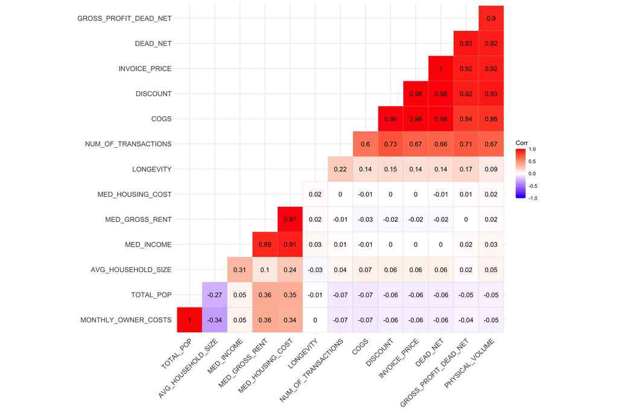

```r
# Checking for multicollinearity and plotting correlations between predictors
correl <- cor(customer_sales[c(19,20,21,22,24,26,27,28,29,30,31,32,33,36)])
ggcorrplot::ggcorrplot(correl,hc.order=TRUE, type="lower",lab=TRUE)
```

```r
cor(correl)
```

```
##                       AVG_HOUSEHOLD_SIZE MED_GROSS_RENT MED_HOUSING_COST
## AVG_HOUSEHOLD_SIZE            1.00000000     0.08075571        0.1707474
## MED_GROSS_RENT                0.08075571     1.00000000        0.9953540
## MED_HOUSING_COST              0.17074736     0.99535402        1.0000000
## MED_INCOME                    0.37154038     0.93556990        0.9541465
## MONTHLY_OWNER_COSTS          -0.64375974     0.43358471        0.3847623
## TOTAL_POP                    -0.61055860     0.44042618        0.3952890
## GROSS_PROFIT_DEAD_NET        -0.13697951    -0.72203860       -0.7372895
## DISCOUNT                     -0.11299645    -0.72983904       -0.7423066
## INVOICE_PRICE                -0.10874198    -0.72518708       -0.7371004
## DEAD_NET                     -0.10929318    -0.72526167       -0.7372159
## PHYSICAL_VOLUME              -0.11349239    -0.69959804       -0.7127727
## COGS                         -0.09832686    -0.72788577       -0.7384400
## NUM_OF_TRANSACTIONS          -0.10894518    -0.72372179       -0.7375152
## LONGEVITY                    -0.18445539    -0.35022260       -0.3728868
##                       MED_INCOME MONTHLY_OWNER_COSTS  TOTAL_POP
## AVG_HOUSEHOLD_SIZE     0.3715404          -0.6437597 -0.6105586
## MED_GROSS_RENT         0.9355699           0.4335847  0.4404262
## MED_HOUSING_COST       0.9541465           0.3847623  0.3952890
## MED_INCOME             1.0000000           0.0972243  0.1073275
## MONTHLY_OWNER_COSTS    0.0972243           1.0000000  0.9989343
## TOTAL_POP              0.1073275           0.9989343  1.0000000
## GROSS_PROFIT_DEAD_NET -0.6136937          -0.5644252 -0.5871738
## DISCOUNT              -0.6162354          -0.5769120 -0.5984472
## INVOICE_PRICE         -0.6114170          -0.5745283 -0.5957893
## DEAD_NET              -0.6117662          -0.5737974 -0.5950603
## PHYSICAL_VOLUME       -0.5892399          -0.5627810 -0.5841980
## COGS                  -0.6124486          -0.5769822 -0.5976141
## NUM_OF_TRANSACTIONS   -0.6028707          -0.5984744 -0.6208108
## LONGEVITY             -0.3037557          -0.2571055 -0.2761181
##                       GROSS_PROFIT_DEAD_NET    DISCOUNT INVOICE_PRICE
## AVG_HOUSEHOLD_SIZE              -0.13697951 -0.11299645   -0.10874198
## MED_GROSS_RENT                  -0.72203860 -0.72983904   -0.72518708
## MED_HOUSING_COST                -0.73728949 -0.74230663   -0.73710044
## MED_INCOME                      -0.61369370 -0.61623543   -0.61141702
## MONTHLY_OWNER_COSTS             -0.56442524 -0.57691204   -0.57452831
## TOTAL_POP                       -0.58717378 -0.59844718   -0.59578928
## GROSS_PROFIT_DEAD_NET            1.00000000  0.99558955    0.99381580
## DISCOUNT                         0.99558955  1.00000000    0.99901386
## INVOICE_PRICE                    0.99381580  0.99901386    1.00000000
```

[output cut: 20 more lines]

```
##                       NUM_OF_TRANSACTIONS   LONGEVITY
## AVG_HOUSEHOLD_SIZE             -0.1089452 -0.18445539
## MED_GROSS_RENT                 -0.7237218 -0.35022260
## MED_HOUSING_COST               -0.7375152 -0.37288675
## MED_INCOME                     -0.6028707 -0.30375568
## MONTHLY_OWNER_COSTS            -0.5984744 -0.25710546
## TOTAL_POP                      -0.6208108 -0.27611809
## GROSS_PROFIT_DEAD_NET           0.9404366  0.09615592
## DISCOUNT                        0.9361975  0.08401187
## INVOICE_PRICE                   0.9214618  0.07604617
## DEAD_NET                        0.9201196  0.07633610
## PHYSICAL_VOLUME                 0.9266039  0.03753745
## COGS                            0.9075761  0.07739067
## NUM_OF_TRANSACTIONS             1.0000000  0.18133921
## LONGEVITY                       0.1813392  1.00000000
```

Checking linear relationship between LONGEVITY - GROSS_PROFIT_DEAD_NET, the relationship is positive but not strong.

```r
# LONGEVITY - GROSS_PROFIT_DEAD_NET
model_lm_GROSS_PROFIT <- lm(LONGEVITY ~ GROSS_PROFIT_DEAD_NET, data = customer_sales)
summary(model_lm_GROSS_PROFIT)
```

```
##
## Call:
## lm(formula = LONGEVITY ~ GROSS_PROFIT_DEAD_NET, data = customer_sales)
##
## Residuals:
##     Min      1Q  Median      3Q     Max
## -32.593  -6.252  -3.200   3.286  31.701
##
## Coefficients:
##                        Estimate Std. Error t value Pr(>|t|)
## (Intercept)           7.219e+00  1.997e-01  36.148   <2e-16 ***
## GROSS_PROFIT_DEAD_NET 1.856e-04  2.122e-05   8.747   <2e-16 ***
## ---
## Signif. codes:  0 '***' 0.001 '**' 0.01 '*' 0.05 '.' 0.1 ' ' 1
##
## Residual standard error: 8.74 on 2664 degrees of freedom
## Multiple R-squared:  0.02792,    Adjusted R-squared:  0.02755
## F-statistic:  76.5 on 1 and 2664 DF,  p-value: < 2.2e-16
```

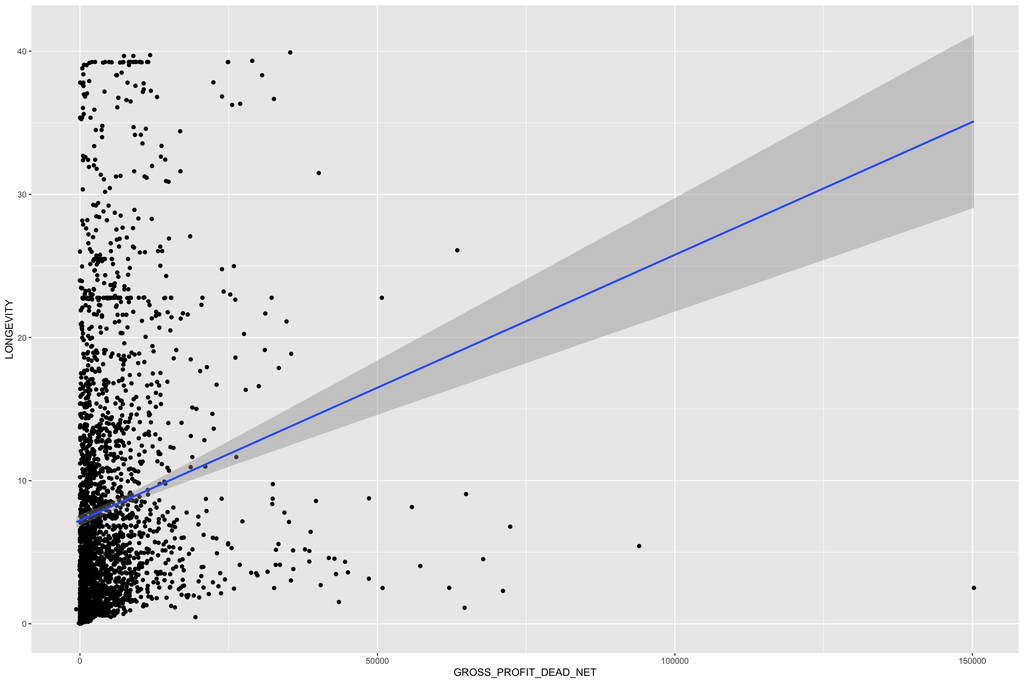

```r
# Relationship visulization
ggplot(customer_sales,aes(x = GROSS_PROFIT_DEAD_NET, y =LONGEVITY)) + geom_point() +geom_smooth(method = "lm")
```

Linear regression for LONGEVITY, r² is 0.1345, Many NA coefficient varibles

```r
#Linear Model for Longevity
lm_LONGEVITY <- lm(customer_sales,formula=LONGEVITY ~  SALES_OFFICE_DESCRIPTION +DELIVERY_PLANT_DESCRIPTION +COUNTY+CUSTOMER_TRADE_CHANNEL_DESCRIPTION+CUSTOMER_SUB_TRADE_CHANNEL_DESCRIPTION+ CUSTOMER_TRADE_CHANNEL_DESCRIPTION2+ AGG_NUM_VEHICLES+AVG_HOUSEHOLD_SIZE+ MED_GROSS_RENT+MED_HOUSING_COST+MED_INCOME+MED_YEAR_BUILT+MONTHLY_OWNER_COSTS+TOTAL_POP+DISCOUNT+NUM_OF_TRANSACTIONS)

summary(lm_LONGEVITY)
```

```
##
## Call:
## lm(formula = LONGEVITY ~ SALES_OFFICE_DESCRIPTION + DELIVERY_PLANT_DESCRIPTION +
##     COUNTY + CUSTOMER_TRADE_CHANNEL_DESCRIPTION + CUSTOMER_SUB_TRADE_CHANNEL_DESCRIPTION +
##     CUSTOMER_TRADE_CHANNEL_DESCRIPTION2 + AGG_NUM_VEHICLES +
##     AVG_HOUSEHOLD_SIZE + MED_GROSS_RENT + MED_HOUSING_COST +
##     MED_INCOME + MED_YEAR_BUILT + MONTHLY_OWNER_COSTS + TOTAL_POP +
##     DISCOUNT + NUM_OF_TRANSACTIONS, data = customer_sales)
##
## Residuals:
##     Min      1Q  Median      3Q     Max
## -30.606  -5.154  -2.344   2.766  34.611
##
## Coefficients: (24 not defined because of singularities)
##                                                              Estimate
## (Intercept)                                                 1.543e+01
## SALES_OFFICE_DESCRIPTIONFlagstaff, AZ                      -1.566e+00
## SALES_OFFICE_DESCRIPTIONLogan, UT                          -7.805e+00
## SALES_OFFICE_DESCRIPTIONOgden, UT                          -3.015e+00
## SALES_OFFICE_DESCRIPTIONPrice, UT                          -7.003e+00
## SALES_OFFICE_DESCRIPTIONRichfield, UT                      -1.262e+01
## DELIVERY_PLANT_DESCRIPTIONFlagstaff, AZ                            NA
## DELIVERY_PLANT_DESCRIPTIONLogan, UT                                NA
## DELIVERY_PLANT_DESCRIPTIONOgden, UT                                NA
## DELIVERY_PLANT_DESCRIPTIONPrice, UT                                NA
## DELIVERY_PLANT_DESCRIPTIONRichfield, UT                            NA
## COUNTYCACHE                                                 3.700e+00
## COUNTYCARBON                                                1.688e+00
## COUNTYDAVIS                                                -3.227e+00
## COUNTYEMERY                                                -2.495e-01
## COUNTYGARFIELD                                              6.242e+00
## COUNTYGRAND                                                -1.052e+00
## COUNTYJUAB                                                 -7.180e+00
## COUNTYMILLARD                                               6.411e+00
## COUNTYMORGAN                                               -4.709e+00
## COUNTYPIUTE                                                 3.564e+00
## COUNTYRICH                                                         NA
## COUNTYSALT LAKE                                            -5.171e+00
## COUNTYSAN JUAN                                                     NA
## COUNTYSANPETE                                               6.675e+00
```

[output cut: 148 more lines]

```
## AVG_HOUSEHOLD_SIZE                                               NA
## MED_GROSS_RENT                                                   NA
## MED_HOUSING_COST                                                 NA
## MED_INCOME                                                       NA
## MED_YEAR_BUILT                                                   NA
## MONTHLY_OWNER_COSTS                                              NA
## TOTAL_POP                                                        NA
## DISCOUNT                                                   0.106113
## NUM_OF_TRANSACTIONS                                         < 2e-16 ***
## ---
## Signif. codes:  0 '***' 0.001 '**' 0.01 '*' 0.05 '.' 0.1 ' ' 1
##
## Residual standard error: 8.245 on 2630 degrees of freedom
## Multiple R-squared:  0.1459, Adjusted R-squared:  0.1345
## F-statistic: 12.83 on 35 and 2630 DF,  p-value: < 2.2e-16
```

Linear Regression for GROSS_PROFIT_DEAD_NET,r² is 0.8556, Many NA coefficient varibles

```r
#Linear model for GROSS_PROFIT_DEAD_NET
lm_Profit <- lm(customer_sales,formula= GROSS_PROFIT_DEAD_NET ~  SALES_OFFICE_DESCRIPTION+DELIVERY_PLANT_DESCRIPTION+COUNTY +CUSTOMER_TRADE_CHANNEL_DESCRIPTION+CUSTOMER_SUB_TRADE_CHANNEL_DESCRIPTION + CUSTOMER_TRADE_CHANNEL_DESCRIPTION2+DISCOUNT+NUM_OF_TRANSACTIONS+ AGG_NUM_VEHICLES+AVG_HOUSEHOLD_SIZE+ MED_GROSS_RENT+MED_HOUSING_COST+MED_INCOME+MED_YEAR_BUILT+MONTHLY_OWNER_COSTS+TOTAL_POP)

summary(lm_Profit)
```

```
##
## Call:
## lm(formula = GROSS_PROFIT_DEAD_NET ~ SALES_OFFICE_DESCRIPTION +
##     DELIVERY_PLANT_DESCRIPTION + COUNTY + CUSTOMER_TRADE_CHANNEL_DESCRIPTION +
##     CUSTOMER_SUB_TRADE_CHANNEL_DESCRIPTION + CUSTOMER_TRADE_CHANNEL_DESCRIPTION2 +
##     DISCOUNT + NUM_OF_TRANSACTIONS + AGG_NUM_VEHICLES + AVG_HOUSEHOLD_SIZE +
##     MED_GROSS_RENT + MED_HOUSING_COST + MED_INCOME + MED_YEAR_BUILT +
##     MONTHLY_OWNER_COSTS + TOTAL_POP, data = customer_sales)
##
## Residuals:
##    Min     1Q Median     3Q    Max
## -31595   -879   -274    628  71766
##
## Coefficients: (24 not defined because of singularities)
##                                                              Estimate
## (Intercept)                                                 2.460e+03
## SALES_OFFICE_DESCRIPTIONFlagstaff, AZ                      -6.067e+02
## SALES_OFFICE_DESCRIPTIONLogan, UT                          -6.556e+02
## SALES_OFFICE_DESCRIPTIONOgden, UT                          -6.240e+02
## SALES_OFFICE_DESCRIPTIONPrice, UT                          -1.680e+03
## SALES_OFFICE_DESCRIPTIONRichfield, UT                      -9.893e+02
## DELIVERY_PLANT_DESCRIPTIONFlagstaff, AZ                            NA
## DELIVERY_PLANT_DESCRIPTIONLogan, UT                                NA
## DELIVERY_PLANT_DESCRIPTIONOgden, UT                                NA
## DELIVERY_PLANT_DESCRIPTIONPrice, UT                                NA
## DELIVERY_PLANT_DESCRIPTIONRichfield, UT                            NA
## COUNTYCACHE                                                -6.501e+02
## COUNTYCARBON                                                3.068e+01
## COUNTYDAVIS                                                -9.906e+02
## COUNTYEMERY                                                 1.086e+02
## COUNTYGARFIELD                                              4.038e+02
## COUNTYGRAND                                                -1.927e+02
## COUNTYJUAB                                                 -9.144e+02
## COUNTYMILLARD                                              -1.139e+02
## COUNTYMORGAN                                               -1.043e+02
## COUNTYPIUTE                                                -1.135e+02
## COUNTYRICH                                                         NA
## COUNTYSALT LAKE                                            -9.469e+02
## COUNTYSAN JUAN                                                     NA
## COUNTYSANPETE                                               1.366e+02
```

[output cut: 148 more lines]

```
## NUM_OF_TRANSACTIONS                                         < 2e-16 ***
## AGG_NUM_VEHICLES                                                 NA
## AVG_HOUSEHOLD_SIZE                                               NA
## MED_GROSS_RENT                                                   NA
## MED_HOUSING_COST                                                 NA
## MED_INCOME                                                       NA
## MED_YEAR_BUILT                                                   NA
## MONTHLY_OWNER_COSTS                                              NA
## TOTAL_POP                                                        NA
## ---
## Signif. codes:  0 '***' 0.001 '**' 0.01 '*' 0.05 '.' 0.1 ' ' 1
##
## Residual standard error: 3032 on 2630 degrees of freedom
## Multiple R-squared:  0.8575, Adjusted R-squared:  0.8556
## F-statistic: 452.3 on 35 and 2630 DF,  p-value: < 2.2e-16
```

Split Data into train & test

```r
#Filter data for LONGEVITY & GROSS_PROFIT_DEAD_NET
CS_L_filtered <- customer_sales [, -c(1,4,5,6,8,9,17,27,29,30,31,32,34,35)]
CS_P_filtered <- customer_sales [, -c(1,4,5,6,8,9,17,29,30,31,32,34,35,36)]

#Split Data tp train and test for LONGEVITY
split = 0.7
trainIndex_L<-createDataPartition(CS_L_filtered$LONGEVITY, p=split, list = FALSE)
train_L<-CS_L_filtered[trainIndex_L, ]
test_L<- CS_L_filtered[-trainIndex_L,]

#Split Data tp train and test for GROSS_PROFIT_DEAD_NET
trainIndex_P<-createDataPartition(CS_P_filtered$GROSS_PROFIT_DEAD_NET, p=split, list = FALSE)
train_P<-CS_P_filtered[trainIndex_P, ]
test_P<- CS_P_filtered[-trainIndex_P,]
```

Class Tree and check for variable importance for LONGEVITY

```r
# Organize Variables to include in Random Forest, same as the variables used in lm regression above
tree_x_L <- factor(c("SALES_OFFICE_DESCRIPTION","DELIVERY_PLANT_DESCRIPTION","COUNTY","CUSTOMER_ACTIVITY_CLUSTER_DESCRIPTION",
"CUSTOMER_TRADE_CHANNEL_DESCRIPTION","CUSTOMER_SUB_TRADE_CHANNEL_DESCRIPTION","CUSTOMER_TRADE_CHANNEL_DESCRIPTION2",
"AGG_NUM_VEHICLES","AVG_HOUSEHOLD_SIZE","MED_GROSS_RENT","MED_HOUSING_COST","MED_INCOME","MED_YEAR_BUILT","MONTHLY_OWNER_COSTS","TOTAL_POP", "DISCOUNT","NUM_OF_TRANSACTIONS" ))

# Fitting Random Forest to the train dataset
set.seed(120)
classifier_RF_L = randomForest(x = train_L[,tree_x_L],
                             y = train_L$LONGEVITY,
                             ntree = 500)
classifier_RF_L
```

```
##
## Call:
##  randomForest(x = train_L[, tree_x_L], y = train_L$LONGEVITY,      ntree = 500)
##                Type of random forest: regression
##                      Number of trees: 500
## No. of variables tried at each split: 5
##
##           Mean of squared residuals: 74.62851
##                     % Var explained: 8.43
```

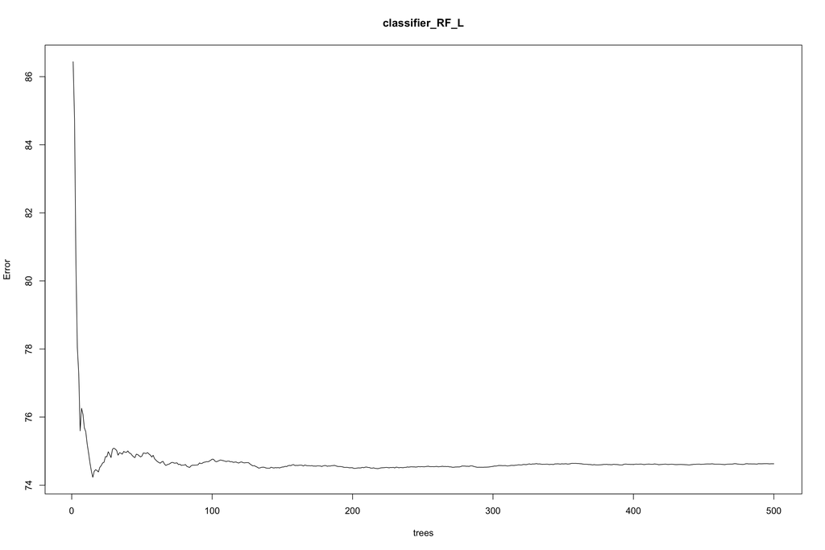

```r
# Plotting model
plot(classifier_RF_L)
```

```r
# Importance plot
importance(classifier_RF_L)
```

```
##                                        IncNodePurity
## MED_YEAR_BUILT                              989.6545
## CUSTOMER_TRADE_CHANNEL_DESCRIPTION2        3465.6703
## COUNTY                                     4548.6787
## CUSTOMER_ACTIVITY_CLUSTER_DESCRIPTION         0.0000
## CUSTOMER_SUB_TRADE_CHANNEL_DESCRIPTION    12567.9509
## CUSTOMER_TRADE_CHANNEL_DESCRIPTION         3105.4759
## BUSINESS_TYPE_EXTENSION_DESCRIPTION           0.0000
## SALES_OFFICE_DESCRIPTION                    931.6910
## DELIVERY_PLANT_DESCRIPTION                  866.3923
## COLD_DRINK_CHANNEL_DESCRIPTION                0.0000
## AGG_NUM_VEHICLES                           1126.9135
## AVG_HOUSEHOLD_SIZE                          924.5064
## MED_GROSS_RENT                              785.9552
## MED_HOUSING_COST                            946.8006
## MONTHLY_OWNER_COSTS                        1130.9757
## MARKET_DESCRIPTION                            0.0000
## MED_INCOME                                  927.8430
```

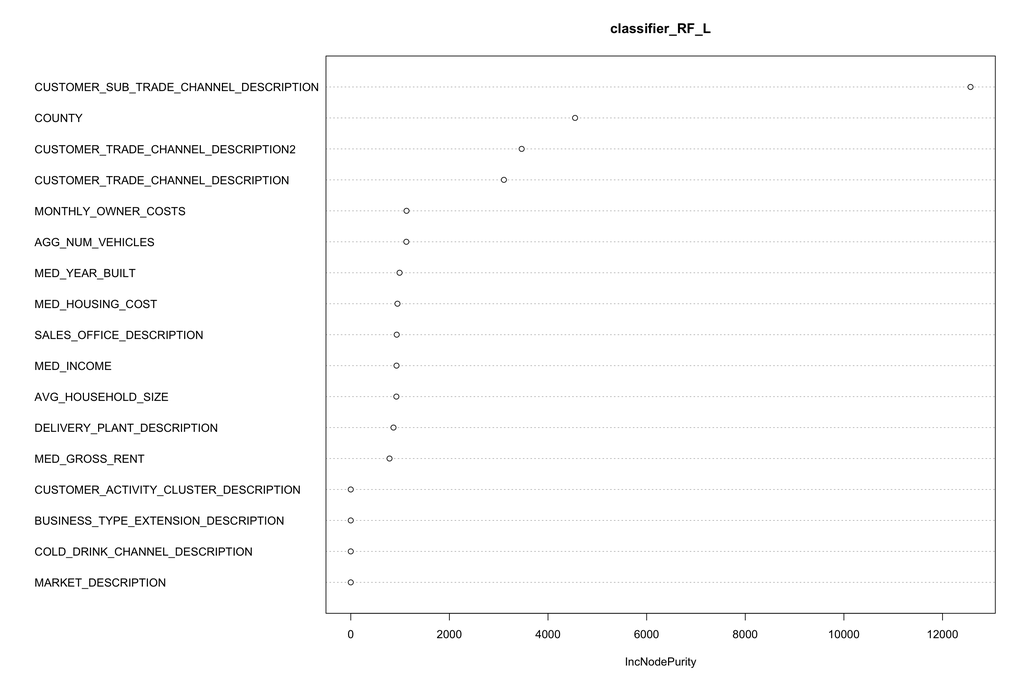

```r
# Variable importance plot
varImpPlot(classifier_RF_L)
```

Class Tree and check for variable importance for GROSS_PROFIT_DEAD_NET

```r
# Organize Variables to include in Random Forest, same as the variables used in lm regression above
tree_x_P <- factor(c("SALES_OFFICE_DESCRIPTION","DELIVERY_PLANT_DESCRIPTION","COUNTY","CUSTOMER_TRADE_CHANNEL_DESCRIPTION", "CUSTOMER_SUB_TRADE_CHANNEL_DESCRIPTION","CUSTOMER_TRADE_CHANNEL_DESCRIPTION2","DISCOUNT","AGG_NUM_VEHICLES","AVG_HOUSEHOLD_SIZE","MED_GROSS_RENT", "MED_HOUSING_COST","MED_INCOME","MED_YEAR_BUILT","MONTHLY_OWNER_COSTS","TOTAL_POP"))

# Fitting Random Forest to the train dataset
set.seed(120)
classifier_RF_P = randomForest(x = train_P[,tree_x_P],
                             y = train_P$GROSS_PROFIT_DEAD_NET,
                             ntree = 500)
classifier_RF_P
```

```
##
## Call:
##  randomForest(x = train_P[, tree_x_P], y = train_P$GROSS_PROFIT_DEAD_NET,      ntree = 500)
##                Type of random forest: regression
##                      Number of trees: 500
## No. of variables tried at each split: 5
##
##           Mean of squared residuals: 63542483
##                     % Var explained: -0.88
```

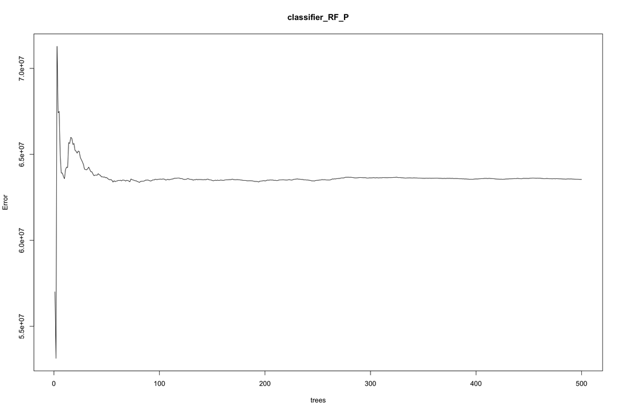

```r
#Plot
plot(classifier_RF_P)
```

```r
# Importance plot
importance(classifier_RF_P)
```

```
##                                        IncNodePurity
## MED_HOUSING_COST                           688396344
## BUSINESS_TYPE_EXTENSION_DESCRIPTION                0
## COUNTY                                    3423472892
## CUSTOMER_TRADE_CHANNEL_DESCRIPTION        1266259570
## CUSTOMER_ACTIVITY_CLUSTER_DESCRIPTION              0
## CUSTOMER_SUB_TRADE_CHANNEL_DESCRIPTION    4806948856
## CUSTOMER_TRADE_CHANNEL_DESCRIPTION2       1244590540
## SALES_OFFICE_DESCRIPTION                   306603588
## DELIVERY_PLANT_DESCRIPTION                 347275915
## MARKET_DESCRIPTION                                 0
## COLD_DRINK_CHANNEL_DESCRIPTION                     0
## AGG_NUM_VEHICLES                           726398503
## AVG_HOUSEHOLD_SIZE                         607782837
## MED_GROSS_RENT                             651074864
## MED_INCOME                                 538553816
```

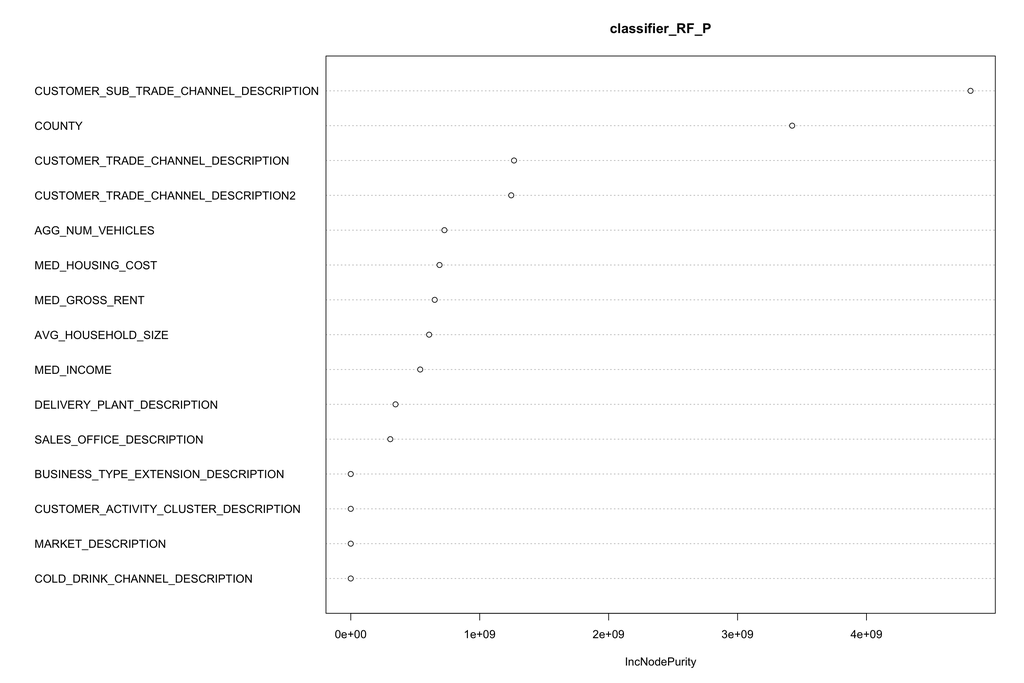

```r
# Variable importance plot
varImpPlot(classifier_RF_P)
```

# 8 Modelling

- Multi Regression
- Lasso
- Ridge
- Kvsm
- Gbm
- Model results comparison

## 8.1 Predicting LONGEVITY

Multi Regression for LONGEVITY

```r
# Define matrix of predictor variables from train
train_x_L <- data.matrix(train_L[,c("SALES_OFFICE_DESCRIPTION","COUNTY","CUSTOMER_TRADE_CHANNEL_DESCRIPTION",
"DELIVERY_PLANT_DESCRIPTION","CUSTOMER_SUB_TRADE_CHANNEL_DESCRIPTION","DISCOUNT","AGG_NUM_VEHICLES","AVG_HOUSEHOLD_SIZE",
"MED_HOUSING_COST","MONTHLY_OWNER_COSTS","TOTAL_POP")])

# Define response variable
train_y_L <- train_L$LONGEVITY

# Define matrix of predictor variables from test
test_x_L <- data.matrix(test_L[,c("SALES_OFFICE_DESCRIPTION","COUNTY","CUSTOMER_TRADE_CHANNEL_DESCRIPTION", "DELIVERY_PLANT_DESCRIPTION","CUSTOMER_SUB_TRADE_CHANNEL_DESCRIPTION","DISCOUNT","AGG_NUM_VEHICLES","AVG_HOUSEHOLD_SIZE", "MED_HOUSING_COST","MONTHLY_OWNER_COSTS","TOTAL_POP")])
test_y_L <- test_L$LONGEVITY

# Multi regression
model_lm_L <- lm(LONGEVITY ~SALES_OFFICE_DESCRIPTION+ COUNTY+DELIVERY_PLANT_DESCRIPTION +CUSTOMER_TRADE_CHANNEL_DESCRIPTION+CUSTOMER_SUB_TRADE_CHANNEL_DESCRIPTION+DISCOUNT +AGG_NUM_VEHICLES+AVG_HOUSEHOLD_SIZE+MED_HOUSING_COST+MONTHLY_OWNER_COSTS+TOTAL_POP,
               data = train_L)
summary(model_lm_L)
```

```
##
## Call:
## lm(formula = LONGEVITY ~ SALES_OFFICE_DESCRIPTION + COUNTY +
##     DELIVERY_PLANT_DESCRIPTION + CUSTOMER_TRADE_CHANNEL_DESCRIPTION +
##     CUSTOMER_SUB_TRADE_CHANNEL_DESCRIPTION + DISCOUNT + AGG_NUM_VEHICLES +
##     AVG_HOUSEHOLD_SIZE + MED_HOUSING_COST + MONTHLY_OWNER_COSTS +
##     TOTAL_POP, data = train_L)
##
## Residuals:
##     Min      1Q  Median      3Q     Max
## -23.088  -5.318  -2.235   2.990  34.824
##
## Coefficients: (17 not defined because of singularities)
##                                                              Estimate
## (Intercept)                                                 1.572e+01
## SALES_OFFICE_DESCRIPTIONFlagstaff, AZ                       5.807e-03
## SALES_OFFICE_DESCRIPTIONLogan, UT                          -8.754e+00
## SALES_OFFICE_DESCRIPTIONOgden, UT                          -2.881e+00
## SALES_OFFICE_DESCRIPTIONPrice, UT                          -5.485e+00
## SALES_OFFICE_DESCRIPTIONRichfield, UT                      -1.199e+01
## COUNTYCACHE                                                 5.217e+00
## COUNTYCARBON                                                3.769e-01
## COUNTYDAVIS                                                -2.766e+00
## COUNTYEMERY                                                 2.729e-01
## COUNTYGARFIELD                                              4.306e+00
## COUNTYGRAND                                                -2.014e+00
## COUNTYJUAB                                                 -6.182e+00
## COUNTYMILLARD                                               7.353e+00
## COUNTYMORGAN                                               -2.388e+00
## COUNTYPIUTE                                                 1.423e+00
## COUNTYRICH                                                         NA
## COUNTYSALT LAKE                                            -5.031e+00
## COUNTYSAN JUAN                                                     NA
## COUNTYSANPETE                                               6.179e+00
## COUNTYSEVIER                                                8.317e+00
## COUNTYSUMMIT                                               -2.957e+00
## COUNTYTOOELE                                               -3.356e+00
## COUNTYUTAH                                                 -5.673e+00
## COUNTYWASATCH                                              -9.104e+00
## COUNTYWAYNE                                                        NA
```

[output cut: 123 more lines]

```
## CUSTOMER_SUB_TRADE_CHANNEL_DESCRIPTIONQSR-Other Fast Food  0.197963
## CUSTOMER_SUB_TRADE_CHANNEL_DESCRIPTIONQSR-Pizza            0.115751
## CUSTOMER_SUB_TRADE_CHANNEL_DESCRIPTIONQSR-Sandwich               NA
## DISCOUNT                                                   3.48e-14 ***
## AGG_NUM_VEHICLES                                                 NA
## AVG_HOUSEHOLD_SIZE                                               NA
## MED_HOUSING_COST                                                 NA
## MONTHLY_OWNER_COSTS                                              NA
## TOTAL_POP                                                        NA
## ---
## Signif. codes:  0 '***' 0.001 '**' 0.01 '*' 0.05 '.' 0.1 ' ' 1
##
## Residual standard error: 8.433 on 1833 degrees of freedom
## Multiple R-squared:  0.1436, Adjusted R-squared:  0.1277
## F-statistic: 9.042 on 34 and 1833 DF,  p-value: < 2.2e-16
```

```r
summary(train_L)
```

```
##   SALES_OFFICE_DESCRIPTION DELIVERY_PLANT_DESCRIPTION       COUNTY
##  Draper, UT   :1369        Draper, UT   :1369         SALT LAKE:802
##  Flagstaff, AZ:   2        Flagstaff, AZ:   2         UTAH     :337
##  Logan, UT    :  61        Logan, UT    :  61         DAVIS    :173
##  Ogden, UT    : 291        Ogden, UT    : 291         WEBER    :144
##  Price, UT    :  59        Price, UT    :  59         SUMMIT   :101
##  Richfield, UT:  86        Richfield, UT:  86         CACHE    : 52
##                                                       (Other)  :259
##   CUSTOMER_ACTIVITY_CLUSTER_DESCRIPTION    CUSTOMER_TRADE_CHANNEL_DESCRIPTION
##  Eating & Drinking   :1868              Quick Service Restau:699
##  At-Work             :   0              Full Service Restaur:619
##  Educational         :   0              Other Eating & Drink:426
##  Entertainment/Recrea:   0              Bar/Tavern/Licensed :107
##  Grocery Shopping    :   0              Street Vendor       : 17
##  Other Shopping & Ser:   0              All Other           :  0
##  (Other)             :   0              (Other)             :  0
##   CUSTOMER_SUB_TRADE_CHANNEL_DESCRIPTION   BUSINESS_TYPE_EXTENSION_DESCRIPTION
##  FSR-All Other       :619                DSD                 :1868
##  Other Eating & Drink:426                Agency              :   0
##  QSR-Other Fast Food :277                Agency/Lcl Dr.Pepper:   0
##  QSR-Mexican         :148                ARTM Distributor    :   0
##  QSR-Pizza           :132                Contract/Bid        :   0
##  Other Bar/Tavern/Lic:107                Equipment Only      :   0
##  (Other)             :159                (Other)             :   0
##    CUSTOMER_TRADE_CHANNEL_DESCRIPTION2 MARKET_DESCRIPTION
##  Quick Service Restau:699              ALL OTHER:   0
##  Full Service Restaur:619              FSOP     :1868
##  Other Eating & Drink:426
##  Bar/Tavern/Licensed :107
##  Street Vendor       : 17
##  All Other           :  0
##  (Other)             :  0
##    COLD_DRINK_CHANNEL_DESCRIPTION AGG_NUM_VEHICLES AVG_HOUSEHOLD_SIZE
##  EATING/DRINKING  :1868           Min.   :   485   Min.   :2.240
##  AT WORK          :   0           1st Qu.:103270   1st Qu.:2.900
##  DESTINATION VENUE:   0           Median :227075   Median :2.920
##  GOV'T/EDU        :   0           Mean   :262533   Mean   :3.076
##  HEALTH/HOSPITAL  :   0           3rd Qu.:458845   3rd Qu.:3.240
##  LODGING          :   0           Max.   :458845   Max.   :3.790
##  (Other)          :   0
```

[output cut: 9 more lines]

```
##  Min.   :   479      Min.   :   22   Min.   :   1809   Min.   :    -6.2
##  1st Qu.: 65026      1st Qu.: 4817   1st Qu.: 259390   1st Qu.:  1890.3
##  Median :122945      Median : 5353   Median : 648265   Median :  6137.6
##  Mean   :152873      Mean   :10015   Mean   : 683628   Mean   : 15765.6
##  3rd Qu.:269187      3rd Qu.:18688   3rd Qu.:1173331   3rd Qu.: 17512.7
##  Max.   :269187      Max.   :18688   Max.   :1173331   Max.   :297155.0
##
##  NUM_OF_TRANSACTIONS   LONGEVITY
##  Min.   :   1.0      Min.   : 0.00742
##  1st Qu.:  46.0      1st Qu.: 1.70910
##  Median : 136.5      Median : 4.97525
##  Mean   : 312.7      Mean   : 8.22447
##  3rd Qu.: 355.0      3rd Qu.:11.30390
##  Max.   :6687.0      Max.   :39.66804
##
```

```r
#Predict
lm_L_predictions <- model_lm_L %>% predict(test_L)
# Overall fit of the prediction model,RMSE & R^2 & MAE
lm_fit_L <- postResample(lm_L_predictions, test_L$LONGEVITY)

# Overall fit of the prediction model,MSE
mse_lm_L <- mean((test_y_L - lm_L_predictions)^2)
print(paste("Test set mean squared error:", mse_lm_L))
```

```
## [1] "Test set mean squared error: 69.0088390643397"
```

Ksvm Model for LONGEVIT

```r
library(kernlab)
# Train ksvm model with default settings
set.seed(123)
ksvm_L <- ksvm(train_L$LONGEVITY ~ SALES_OFFICE_DESCRIPTION+ COUNTY+DELIVERY_PLANT_DESCRIPTION +CUSTOMER_TRADE_CHANNEL_DESCRIPTION+CUSTOMER_SUB_TRADE_CHANNEL_DESCRIPTION+DISCOUNT +AGG_NUM_VEHICLES+AVG_HOUSEHOLD_SIZE+MED_HOUSING_COST+MONTHLY_OWNER_COSTS+TOTAL_POP,
                data = train_L)

# Overall fit of the prediction model,RMSE & R^2 & MAE
ksvm_predictions_test_L <- predict(ksvm_L,test_L)
ksvm_fit_L <- postResample(ksvm_predictions_test_L, test_L$LONGEVITY)

# Overall fit of the prediction model,MSE
mse_ksvm_L <- mean((test_y_L - ksvm_predictions_test_L)^2)
print(paste("Test set mean squared error:", mse_ksvm_L))
```

```
## [1] "Test set mean squared error: 66.611823017036"
```

Gbm Model for LONGEVITY

```r
library(gbm)
# Fit a gradient boosting regression model with 100 trees and 0.01 shrinkage
gbm_L = gbm(train_L$LONGEVITY ~ SALES_OFFICE_DESCRIPTION+ COUNTY+DELIVERY_PLANT_DESCRIPTION +CUSTOMER_TRADE_CHANNEL_DESCRIPTION+CUSTOMER_SUB_TRADE_CHANNEL_DESCRIPTION+DISCOUNT +AGG_NUM_VEHICLES+AVG_HOUSEHOLD_SIZE+MED_HOUSING_COST+MONTHLY_OWNER_COSTS+TOTAL_POP,
                data = train_L,
                distribution = "gaussian",
                cv.folds = 10,
                shrinkage = .01,
                n.minobsinnode = 10,
                n.trees = 500)


gbm_predictions_test_L <- predict.gbm(gbm_L, test_L)
```

```
## Using 499 trees...
```

```r
# Evaluate the performance of the model on the test set
gbm_fit_L <- postResample(gbm_predictions_test_L, test_L$LONGEVITY)
mse_gbm_L <- mean((test_L$LONGEVITY - gbm_predictions_test_L)^2)
print(paste("Random Forest Regression MSE:", mse_gbm_L))
```

```
## [1] "Random Forest Regression MSE: 66.3263146195946"
```

## 8.2 Predicting GROSS_PROFIT_DEAD_NET

Multi Regression for GROSS_PROFIT_DEAD_NET

```r
# Define matrix of predictor variables from train
train_x_P <- data.matrix(train_P[,c("SALES_OFFICE_DESCRIPTION","COUNTY","CUSTOMER_TRADE_CHANNEL_DESCRIPTION","CUSTOMER_SUB_TRADE_CHANNEL_DESCRIPTION","DISCOUNT","MED_HOUSING_COST","MED_INCOME","MED_YEAR_BUILT","MONTHLY_OWNER_COSTS","TOTAL_POP")])

# Define response variable
train_y_P <- train_P$GROSS_PROFIT_DEAD_NET

# Define matrix of predictor variables from test
test_x_P <- data.matrix(test_P[,c("SALES_OFFICE_DESCRIPTION","COUNTY","CUSTOMER_TRADE_CHANNEL_DESCRIPTION","CUSTOMER_SUB_TRADE_CHANNEL_DESCRIPTION","DISCOUNT","MED_HOUSING_COST","MED_INCOME","MED_YEAR_BUILT","MONTHLY_OWNER_COSTS","TOTAL_POP")])
test_y_P <- test_P$GROSS_PROFIT_DEAD_NET

# Multi regression
model_lm_P <- lm(GROSS_PROFIT_DEAD_NET~SALES_OFFICE_DESCRIPTION+COUNTY+CUSTOMER_TRADE_CHANNEL_DESCRIPTION+
                   CUSTOMER_SUB_TRADE_CHANNEL_DESCRIPTION+DISCOUNT++AVG_HOUSEHOLD_SIZE+ MED_INCOME+MED_YEAR_BUILT+MONTHLY_OWNER_COSTS+TOTAL_POP,
               data = train_P)

#Prediction
lm_P_predictions <- model_lm_P %>% predict(test_P)
# Overall fit of the prediction model,RMSE & R^2 & MAE
lm_fit_P <- postResample(lm_P_predictions, test_P$GROSS_PROFIT_DEAD_NET)

# Overall fit of the prediction model,MSE
mse_lm_P <- mean((test_y_P - lm_P_predictions)^2)
print(paste("Test set mean squared error:", mse_lm_P))
```

```
## [1] "Test set mean squared error: 9130037.57755307"
```

```r
#perform k-fold cross-validation to find optimal lambda value
cv_lasso_model_P <- cv.glmnet(train_x_P, train_y_P, alpha = 1, standardize = TRUE, nfolds = 5)

# Find optimal lambda value that minimizes test MSE
best_lambda_lasso_P <- cv_lasso_model_P$lambda.min
best_lambda_lasso_P #399.5965
```

```
## [1] 7.407757
```

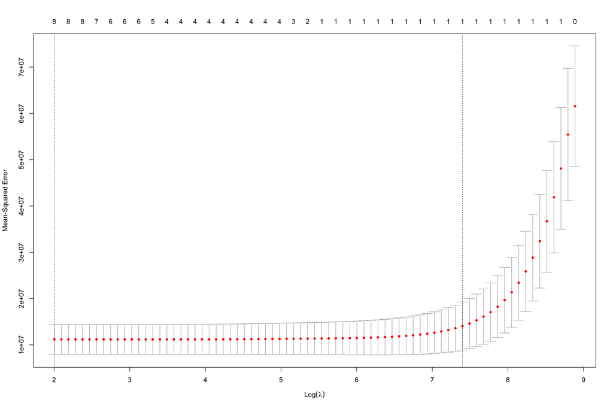

```r
# Produce plot of test MSE by lambda value
plot(cv_lasso_model_P)
```

```r
# Find coefficients of best model
best_lasso_model_P <- glmnet(train_x_P, train_y_P, alpha = 1, lambda = best_lambda_lasso_P)
coef(best_lasso_model_P)
```

```
## 11 x 1 sparse Matrix of class "dgCMatrix"
##                                                   s0
## (Intercept)                             1.254769e+05
## SALES_OFFICE_DESCRIPTION               -1.047034e+02
## COUNTY                                 -9.506496e-01
## CUSTOMER_TRADE_CHANNEL_DESCRIPTION     -4.845129e+01
## CUSTOMER_SUB_TRADE_CHANNEL_DESCRIPTION  2.009918e+00
## DISCOUNT                                2.496897e-01
## MED_HOUSING_COST                        .
## MED_INCOME                              2.018249e-02
## MED_YEAR_BUILT                         -6.298140e+01
## MONTHLY_OWNER_COSTS                     .
## TOTAL_POP                              -3.593015e-04
```

```r
# Prediction with lasso
lasso_predictions_test_P <- predict(best_lasso_model_P,s = best_lambda_lasso_P,newx = test_x_P)


# Overall fit of the prediction model,RMSE & R^2 & MAE
lasso_fit_P <-postResample(lasso_predictions_test_P, test_P$GROSS_PROFIT_DEAD_NET)

# Overall fit of the prediction model,MSE
mse_lasso_P <- mean((test_y_P - lasso_predictions_test_P)^2)
print(paste("Test set mean squared error:", mse_lasso_P))
```

```
## [1] "Test set mean squared error: 9148569.46375252"
```

Ridge for GROSS_PROFIT_DEAD_NET

```r
# Perform k-fold cross-validation to find optimal lambda value
cv_ridge_P <- cv.glmnet(train_x_P, train_y_P, alpha = 0, standardize = TRUE, nfolds = 5)

# Find optimal lambda value that minimizes test MSE
best_lambda_ridge_P <- cv_ridge_P$lambda.min
best_lambda_ridge_P # 5533.958
```

```
## [1] 723.7452
```

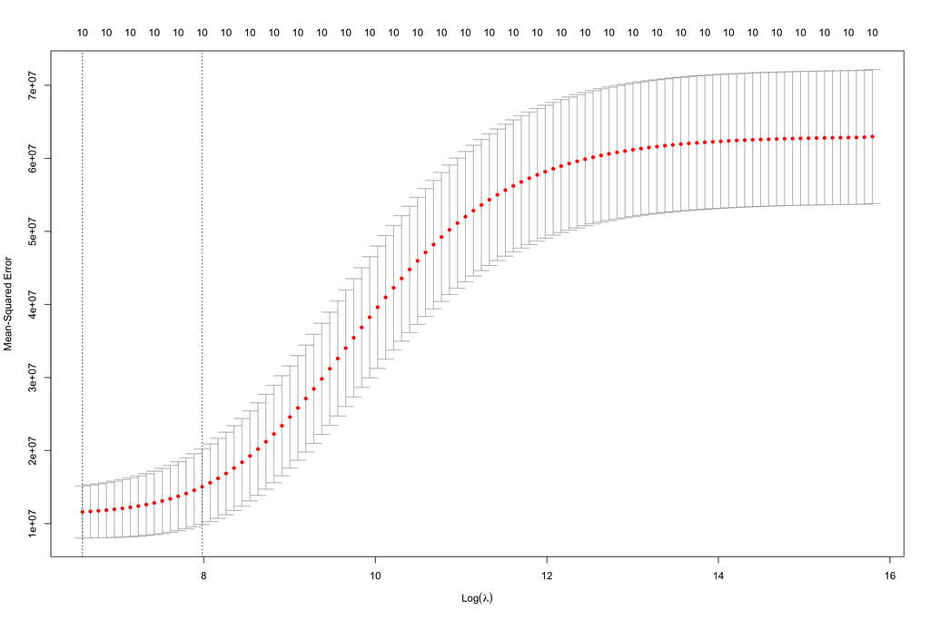

```r
# Produce plot of test MSE by lambda value
plot(cv_ridge_P)
```

```r
# Find coefficients of best model
best_ridge_model_P <- glmnet(train_x_P, train_y_P, alpha = 0, lambda = best_lambda_ridge_P, standardize = TRUE)
coef(best_ridge_model_P)
```

```
## 11 x 1 sparse Matrix of class "dgCMatrix"
##                                                   s0
## (Intercept)                             9.613094e+04
## SALES_OFFICE_DESCRIPTION               -7.712062e+01
## COUNTY                                 -4.966734e+00
## CUSTOMER_TRADE_CHANNEL_DESCRIPTION     -4.001643e+01
## CUSTOMER_SUB_TRADE_CHANNEL_DESCRIPTION  2.963051e+00
## DISCOUNT                                2.286802e-01
## MED_HOUSING_COST                        3.603791e-01
## MED_INCOME                              1.221661e-02
## MED_YEAR_BUILT                         -4.802362e+01
## MONTHLY_OWNER_COSTS                    -1.988884e-04
## TOTAL_POP                              -3.047412e-04
```

```r
# Prediction with ridge
ridge_predictions_test_P <- predict(best_ridge_model_P,s = best_lambda_ridge_P,newx = test_x_P)

# Overall fit of the prediction model,RMSE & R^2 & MAE
ridge_fit_P <- postResample(ridge_predictions_test_P, test_P$GROSS_PROFIT_DEAD_NET)

# Overall fit of the prediction model,MSE
mse_ridge_P <- mean((test_y_P - ridge_predictions_test_P)^2)
print(paste("Test set mean squared error:", mse_ridge_P))
```

```
## [1] "Test set mean squared error: 9330821.06406469"
```

ksvm Model for GROSS_PROFIT_DEAD_NET

```r
# Train ksvm model with default settings
set.seed(123)
ksvm_P <- ksvm(train_P$GROSS_PROFIT_DEAD_NET ~ SALES_OFFICE_DESCRIPTION+COUNTY+CUSTOMER_TRADE_CHANNEL_DESCRIPTION+
                   CUSTOMER_SUB_TRADE_CHANNEL_DESCRIPTION+DISCOUNT++AVG_HOUSEHOLD_SIZE+ MED_INCOME+MED_YEAR_BUILT+MONTHLY_OWNER_COSTS+TOTAL_POP,
                data = train_P)

# Overall fit of the prediction model,RMSE & R^2 & MAE
ksvm_predictions_test_P <- predict(ksvm_P,test_P)
ksvm_fit_P <- postResample(ksvm_predictions_test_P, test_P$GROSS_PROFIT_DEAD_NET)

# Overall fit of the prediction model,MSE
mse_ksvm_P <- mean((test_y_P - ksvm_predictions_test_P)^2)
print(paste("Test set mean squared error:", mse_ksvm_P))
```

```
## [1] "Test set mean squared error: 12074731.4909197"
```

Gbm Model for GROSS_PROFIT_DEAD_NET

```r
# Fit a gradient boosting regression model with 100 trees and 0.01 shrinkage
gbm_P = gbm(train_P$GROSS_PROFIT_DEAD_NET ~SALES_OFFICE_DESCRIPTION+COUNTY+CUSTOMER_TRADE_CHANNEL_DESCRIPTION+
                   CUSTOMER_SUB_TRADE_CHANNEL_DESCRIPTION+DISCOUNT++AVG_HOUSEHOLD_SIZE+ MED_INCOME+MED_YEAR_BUILT+MONTHLY_OWNER_COSTS+TOTAL_POP,
                data = train_P,
                distribution = "gaussian",
                cv.folds = 10,
                shrinkage = .01,
                n.minobsinnode = 10,
                n.trees = 500)


gbm_predictions_test_P <- predict.gbm(gbm_P, test_P)
```

```
## Using 489 trees...
```

```r
# Evaluate the performance of the model on the test set
gbm_fit_P <- postResample(gbm_predictions_test_P, test_P$GROSS_PROFIT_DEAD_NET)
mse_gbm_P <- mean((test_P$GROSS_PROFIT_DEAD_NET - gbm_predictions_test_P)^2)
print(paste("Random Forest Regression MSE:", mse_gbm_P))
```

```
## [1] "Random Forest Regression MSE: 9656588.32271915"
```